# Practical Machine Learning Course Project

Amelia S

## Background

Using devices such as Jawbone Up, Nike FuelBand, and Fitbit it is now possible to collect a large amount of data about personal activity relatively inexpensively. These type of devices are part of the quantified self movement – a group of enthusiasts who take measurements about themselves regularly to improve their health, to find patterns in their behavior, or because they are tech geeks. One thing that people regularly do is quantify how much of a particular activity they do, but they rarely quantify how well they do it. In this project, your goal will be to use data from accelerometers on the belt, forearm, arm, and dumbell of 6 participants. They were asked to perform barbell lifts correctly and incorrectly in 5 different ways. More information is available from the website here: http://groupware.les.inf.puc-rio.br/har (see the section on the Weight Lifting Exercise Dataset).

## Data

The training data for this project are available here:

https://d396qusza40orc.cloudfront.net/predmachlearn/pml-training.csv

The test data are available here:

https://d396qusza40orc.cloudfront.net/predmachlearn/pml-testing.csv

## Load the data

```r
setwd("~/Desktop")
library(caret)
pmltrain <- read.csv("pml-training.csv", na.strings = c("", "NA", "#DIV/0!"))
pmltest <- read.csv("pml-testing.csv", na.strings = c("", "NA", "#DIV/0!"))
```

## Data Partition

Partition the data so that 75% is training and 25% is testing

```r
inTrain <- createDataPartition(y = pmltrain$classe, p = 0.75, list = FALSE)
ftrain <- pmltrain[inTrain,]
ftest <- pmltrain[-inTrain,]
```

## Clean the data

I want the nonzero data.

```r
all_zero_colnames <- sapply(names(pmltest), function(x) all(is.na(pmltest[,x])==TRUE))
nznames <- names(all_zero_colnames)[all_zero_colnames==FALSE]
nznames <- nznames[-(1:7)]
nznames <- nznames[1:(length(nznames)-1)]
```

## Model and Cross-Validation

```r
library(randomForest)
trc <- trainControl(method = "cv", number = 3)
fitgbm <- train(classe ~ ., data=ftrain[, c('classe', nznames)], trControl=trc, method='gbm')
save(fitgbm, file='./fitgbm.RData')
predgbm <- predict(fitgbm, ftest)
cmgbm <- confusionMatrix(predgbm, ftest$classe)
## Check the accuracy of this model
cmgbm$overall[1]
```

```
## Accuracy
##  0.96146
```

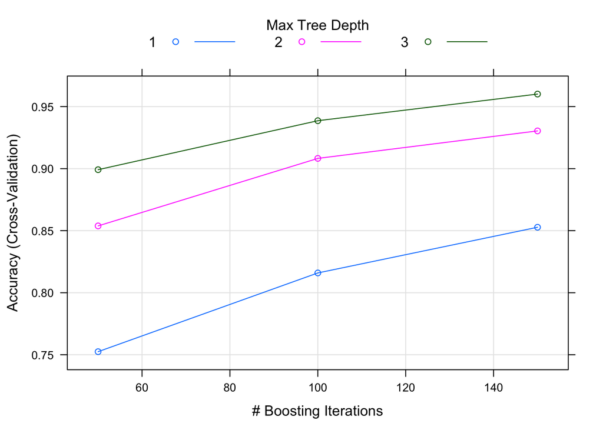

```r
plot(fitgbm)
```

```r
fitrf <- train(classe ~ ., data=ftrain[, c('classe', nznames)], trControl=trc, method='rf', ntree=100)
save(fitrf, file='./fitrf.RData')
predrf <- predict(fitrf, ftest)
cmrf <- confusionMatrix(predrf, ftest$classe)
## Check the accuracy of this model
cmrf$overall[1]
```

```
## Accuracy
## 0.992863
```

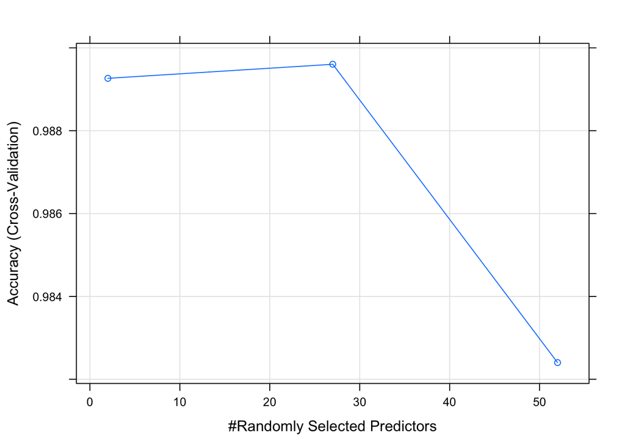

```r
plot(fitrf)
```

## Conclusion

From the above results, it shows that the random forest approach is much more accurate compared to the gradient boosting trees method. Below is the confusion matrix for the random forest model.

```
## Confusion Matrix and Statistics
##
##           Reference
## Prediction    A    B    C    D    E
##          A 1394    9    0    0    0
##          B    1  937    6    0    0
##          C    0    3  843    7    1
##          D    0    0    6  796    1
##          E    0    0    0    1  899
##
## Overall Statistics
##
##                Accuracy : 0.9929
##                  95% CI : (0.9901, 0.995)
##     No Information Rate : 0.2845
##     P-Value [Acc > NIR] : < 2.2e-16
##
##                   Kappa : 0.991
##  Mcnemar's Test P-Value : NA
##
## Statistics by Class:
##
##                      Class: A Class: B Class: C Class: D Class: E
## Sensitivity            0.9993   0.9874   0.9860   0.9900   0.9978
## Specificity            0.9974   0.9982   0.9973   0.9983   0.9998
## Pos Pred Value         0.9936   0.9926   0.9871   0.9913   0.9989
## Neg Pred Value         0.9997   0.9970   0.9970   0.9980   0.9995
## Prevalence             0.2845   0.1935   0.1743   0.1639   0.1837
## Detection Rate         0.2843   0.1911   0.1719   0.1623   0.1833
## Detection Prevalence   0.2861   0.1925   0.1741   0.1637   0.1835
## Balanced Accuracy      0.9984   0.9928   0.9916   0.9942   0.9988
```

## Prediction Quiz using the rf model

```
##  [1] B A B A A E D B A A B C B A E E A B B B
## Levels: A B C D E
```